# An Investigation of Grade 3-5 Students’ State Test Scores in the Denver, Colorado Area

Frances Lin

5/2019

## I. DESCRIPTION

State test score ranges from 4 to 36 and has a mean equal to 25.13 and a median equal to 25. English portion of the score ranges from 0 to 98 and has a mean equal to 52.49 and a median equal to 54, and math portion of the score ranges from 1 to 40 and has a mean equal to 26.66 and a median equal to 28. Gender has two levels (1: boy, 2: girl). Grade ranges from 3 to 5 (1154 scores were taken in grade 3; 1129 scores were taken in grade 4; and 953 scores were taken in grade 5). Parents’ employment has 9 levels (1: both parents employed, manual laborers; 2: father manual labor, mother non-manual labor; 3: father non-manual labor, mother manual labor; 4: both parents non-manual labor; 5: father employed, mother unemployed; 6: father unemployed, mother employed; 7: both parents long term unemployed; 8: both parents currently employed; 9: father absent).

```r
library(GGally)
```

```r
library(ggplot2)
library(gridExtra)
library(car)
load(file="ScoreData.RData")
str(ScoreData)
```

```
## 'data.frame':    3236 obs. of  8 variables:
##  $ school.id: Factor w/ 49 levels "1","2","3","4",..: 1 1 1 1 1 1 1 1 1 1 ...
##  $ gender   : Factor w/ 2 levels "boy","girl": 2 2 2 1 1 1 1 1 1 1 ...
##  $ employ   : Factor w/ 9 levels "1","2","3","4",..: 9 9 9 2 2 2 2 2 9 9 ...
##  $ t.score  : int  23 23 23 15 15 22 22 22 14 14 ...
##  $ ID       : Factor w/ 1192 levels "1","2","3","4",..: 1 1 1 2 2 3 3 3 4 4 ...
##  $ english  : int  72 80 39 7 17 88 89 83 12 25 ...
##  $ math     : int  23 24 23 14 11 36 32 39 24 26 ...
##  $ grade    : Factor w/ 3 levels "3","4","5": 1 2 3 1 2 1 2 3 1 2 ...
```

```r
# Attach data set
attach(ScoreData)

# Summary Statistics
summary(ScoreData)
```

```
##    school.id     gender         employ        t.score            ID
##  48     : 206   boy :1551   4      :1225   Min.   : 4.00   1      :   3
##  33     : 131   girl:1685   9      : 484   1st Qu.:21.00   3      :   3
##  42     : 131               2      : 424   Median :25.00   4      :   3
##  31     : 107               5      : 288   Mean   :25.13   6      :   3
##  47     : 102               3      : 270   3rd Qu.:29.00   7      :   3
##  50     : 101               6      : 221   Max.   :36.00   8      :   3
##  (Other):2458               (Other): 324                   (Other):3218
##     english           math       grade
##  Min.   : 0.00   Min.   : 1.00   3:1154
##  1st Qu.:31.00   1st Qu.:22.00   4:1129
##  Median :54.00   Median :28.00   5: 953
##  Mean   :52.49   Mean   :26.66
##  3rd Qu.:75.00   3rd Qu.:33.00
##  Max.   :98.00   Max.   :40.00
##
```

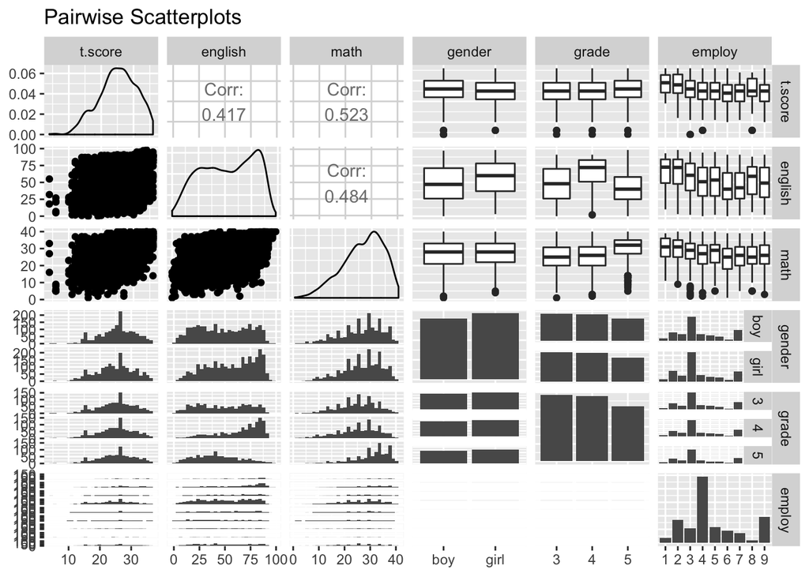

```r
# Reorder columns
ScoreData <- ScoreData[c(1,5,4,6,7,2,8,3)]
#View(ScoreData)

# Pairwise Scatterplots using ggplot2
ggpairs(ScoreData[c(-1,-2)]) + ggtitle("Pairwise Scatterplots")
```

## II. ANALYSIS

**1. The first part of the analysis investigates the relationship between state test score (t.score) and English portion of the score (english) vs. the relationship between state test score (t.score) math potion of the score (math).**

Initially, it appears that the relationship is consistent across test portion. Specifically, a higher English score is associated with a higher test score, a higher math score is associated with a higher test score, and both relationships appear linear. (It is worth nothing that the LOESS model does not fit well, and log-transformation is recommended.) However, when parents’ employment type is controlled for, it appears that the relationship is not consistent across test portion. For example, when both parents are non-manual labors (employ=4), the relationship appears consistent. On the other hand, when both parents are currently employed (employ=8), one relationship appears polynomial, and the other appears logarithmic.

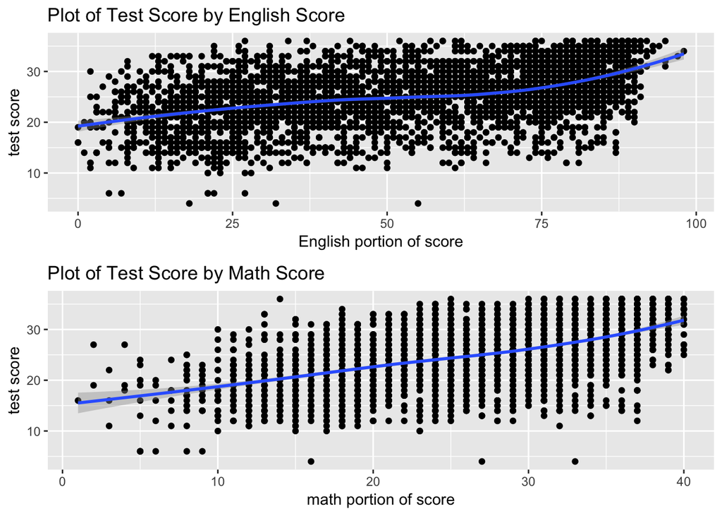

```r
# Ques 1a: x=english, y=t.score, based on employ
g1 <- ggplot(ScoreData, aes(x=english, y=t.score)) +
  labs(title="Plot of Test Score by English Score", x="English portion of score", y="test score")
geng0 <- g1 + geom_point() + geom_smooth(method="loess")
geng <- g1 + geom_point() + geom_smooth(method="loess") +
  facet_grid(.~employ) + ggtitle("Plot of Test Score by English Score based on Parents' Employment")

# Ques 1b: x=math, y=t.score, based on employ
g11 <- ggplot(ScoreData, aes(x=math, y=t.score)) +
  labs(title="Plot of Test Score by Math Score", x="math portion of score", y="test score")
gmath0 <- g11 + geom_point() + geom_smooth(method="loess")
gmath <- g11 + geom_point() + geom_smooth(method="loess") +
  facet_grid(.~employ) + ggtitle("Plot of Test Score by Math Score based on Parents' Employment")

# Combine Plots of Test Score by English Score and by Math Score
grid.arrange(geng0, gmath0, nrow=2)
```

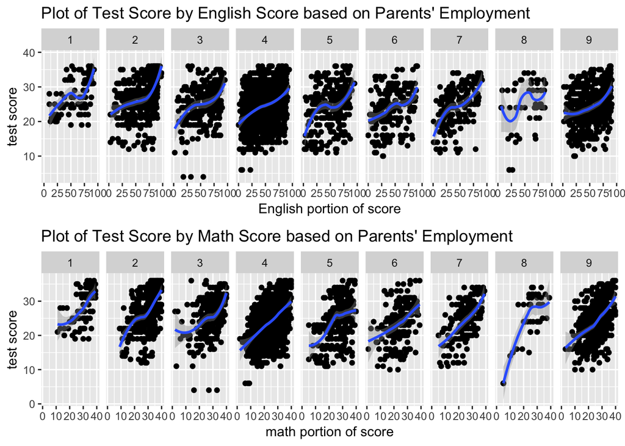

```r
grid.arrange(geng, gmath, nrow=2)
```

```r
# Fit simple linear regression model for Ques 1
lmeng <- lm(t.score~english)
lmmath <- lm(t.score~math)
summary(lmeng, type=3)   #p=< 2.2e-16 ***
```

```
##
## Call:
## lm(formula = t.score ~ english)
##
## Residuals:
##      Min       1Q   Median       3Q      Max
## -21.3717  -3.4553   0.2956   3.8827  13.3744
##
## Coefficients:
##              Estimate Std. Error t value Pr(>|t|)
## (Intercept) 19.977539   0.217829   91.71   <2e-16 ***
## english      0.098075   0.003755   26.12   <2e-16 ***
## ---
## Signif. codes:  0 '***' 0.001 '**' 0.01 '*' 0.05 '.' 0.1 ' ' 1
##
## Residual standard error: 5.277 on 3234 degrees of freedom
## Multiple R-squared:  0.1742, Adjusted R-squared:  0.174
## F-statistic: 682.3 on 1 and 3234 DF,  p-value: < 2.2e-16
```

```r
summary(lmmath, type=3)  #p=< 2.2e-16 ***
```

```
##
## Call:
## lm(formula = t.score ~ math)
##
## Residuals:
##      Min       1Q   Median       3Q      Max
## -23.6481  -3.2603   0.3316   3.5458  15.9133
##
## Coefficients:
##             Estimate Std. Error t value Pr(>|t|)
## (Intercept) 14.51510    0.31592   45.95   <2e-16 ***
## math         0.39797    0.01139   34.94   <2e-16 ***
## ---
## Signif. codes:  0 '***' 0.001 '**' 0.01 '*' 0.05 '.' 0.1 ' ' 1
##
## Residual standard error: 4.948 on 3234 degrees of freedom
## Multiple R-squared:  0.274,  Adjusted R-squared:  0.2738
## F-statistic:  1221 on 1 and 3234 DF,  p-value: < 2.2e-16
```

```r
lmengc <- lm(t.score~english+employ)
lmmathc <- lm(t.score~math+employ)
Anova(lmengc, type=3)    #p=< 2.2e-16 *** and p=8.154e-10 ***
```

```
## Anova Table (Type III tests)
##
## Response: t.score
##             Sum Sq   Df   F value    Pr(>F)
## (Intercept)  40089    1 1462.3065 < 2.2e-16 ***
## english      15772    1  575.3048 < 2.2e-16 ***
## employ        1624    8    7.4054 8.154e-10 ***
## Residuals    88441 3226
## ---
## Signif. codes:  0 '***' 0.001 '**' 0.01 '*' 0.05 '.' 0.1 ' ' 1
```

```r
Anova(lmmathc, type=3)   #p=< 2.2e-16 *** and p=4.514e-10 ***
```

```
## Anova Table (Type III tests)
##
## Response: t.score
##             Sum Sq   Df   F value    Pr(>F)
## (Intercept)  18683    1  775.4661 < 2.2e-16 ***
## math         26490    1 1099.5289 < 2.2e-16 ***
## employ        1459    8    7.5721 4.514e-10 ***
## Residuals    77722 3226
## ---
## Signif. codes:  0 '***' 0.001 '**' 0.01 '*' 0.05 '.' 0.1 ' ' 1
```

**2. The second part of the analysis investigates the relationship between state test score (t.score) and student’s grade (grade).**

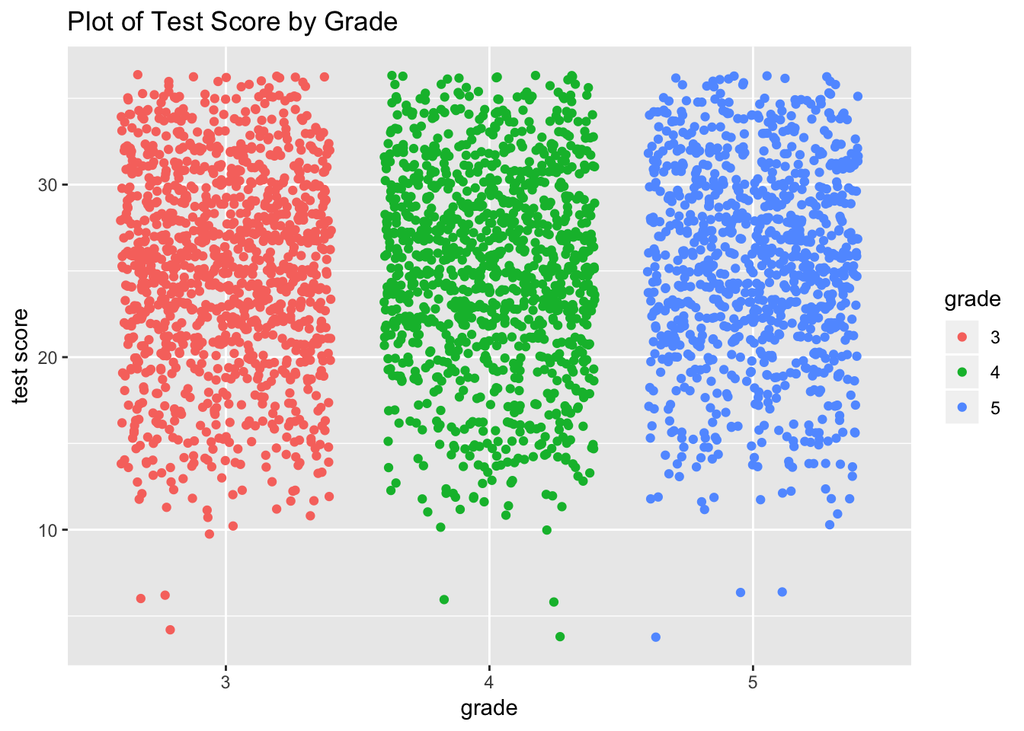

```r
# Ques 2: x=grade, y=t.score, based on employ
g2 <- ggplot(ScoreData, aes(x=grade, y=t.score, color=grade)) +
  labs(title="Plot of Test Score by Grade", y="test score")
g2 + geom_jitter()
```

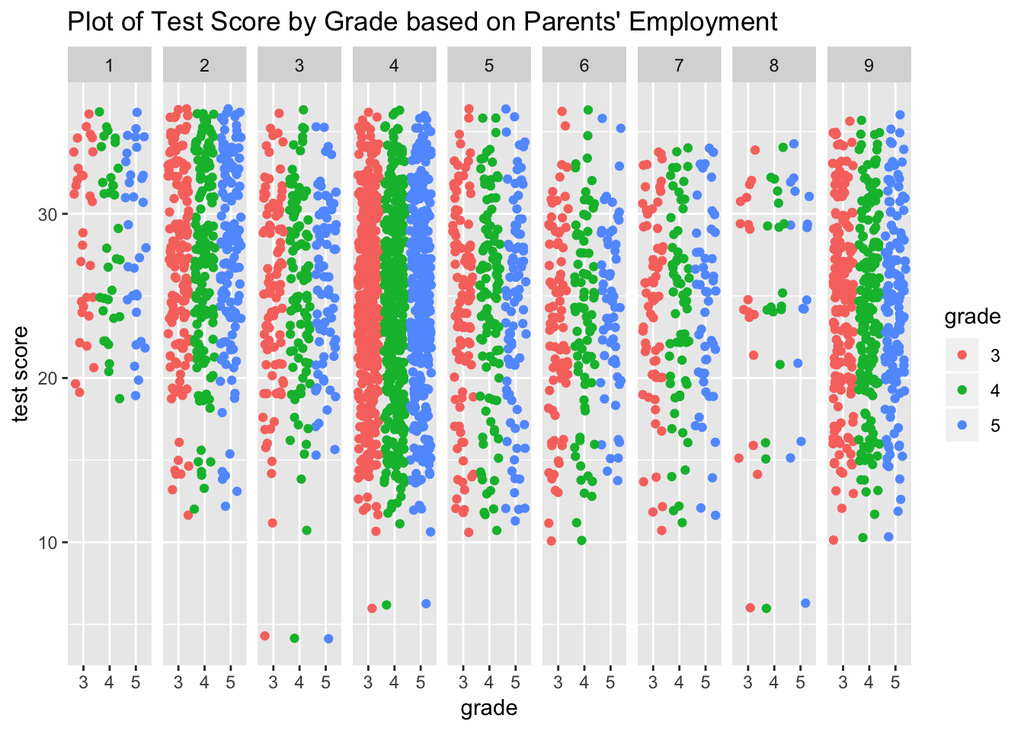

```r
g2 + geom_jitter() + facet_grid(.~employ) +
  ggtitle("Plot of Test Score by Grade based on Parents' Employment")
```

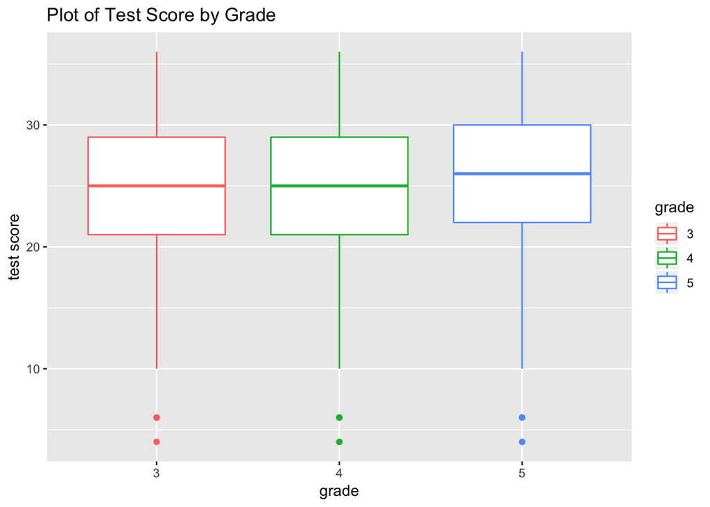

```r
g2 + geom_boxplot()
```

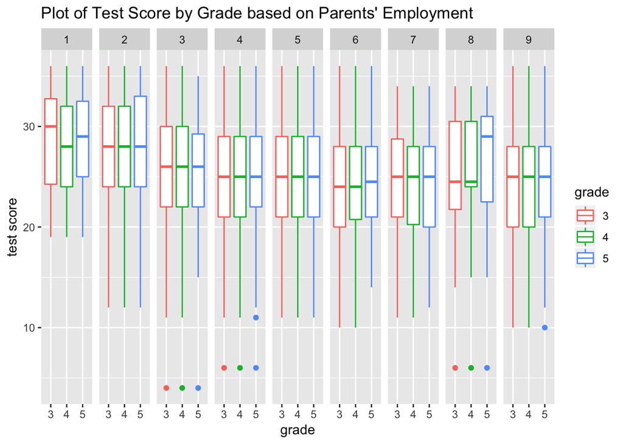

```r
g2 + geom_boxplot() + facet_grid(.~employ) +
  ggtitle("Plot of Test Score by Grade based on Parents' Employment")
```

```r
# Fit simple linear regression model for Ques 2
lmgrade <- lm(t.score~grade)
lmgradec <- lm(t.score~grade+employ)
Anova(lmgrade, type=3)   #p=0.4244
```

```
## Anova Table (Type III tests)
##
## Response: t.score
##             Sum Sq   Df    F value Pr(>F)
## (Intercept) 723652    1 21461.9483 <2e-16 ***
## grade           58    2     0.8573 0.4244
## Residuals   109010 3233
## ---
## Signif. codes:  0 '***' 0.001 '**' 0.01 '*' 0.05 '.' 0.1 ' ' 1
```

```r
Anova(lmgradec, type=3)  #p=0.5039 and p=<2e-16 ***
```

```
## Anova Table (Type III tests)
##
## Response: t.score
##             Sum Sq   Df   F value Pr(>F)
## (Intercept)  71747    1 2221.2322 <2e-16 ***
## grade           44    2    0.6855 0.5039
## employ        4841    8   18.7357 <2e-16 ***
## Residuals   104169 3225
## ---
## Signif. codes:  0 '***' 0.001 '**' 0.01 '*' 0.05 '.' 0.1 ' ' 1
```

**3. The third part of the analysis investigates the relationship between state test score (t.score) and student’s gender (gender).**